# Introduction

We saw in `analysis-01-dynamics` that we could effectively separate the corn plants from the NPC. Here we want to show something fairly obvious: that we can replicate that work using soft thresholding, as opposed to hard thresholding. This shouldn't be too surprising as a sigmoid function approaches a step function as its slope increases.

We break this up into two parts. First, in part "A", we replicate the work from `analysis-01-dynamics` using soft thresholding. There is no inference here, but we do make use of functions from the "rtphenos" package. Second, in part "B", we show that we can infer the parameters of interest for the same model. This can be computationally intensive, so we have split it off as a separate notebook that can be run in, e.g. Google Colab.

In `inference-01-dynamics-01-univariate`, we built some intuition about how to build a good, basic model, and we use some of that intuition here, so you might want to review that notebook.

# Setup

Import stuff and determine device we will use for computations

```python
import os
import copy
import h5py
import pandas as pd
import numpy as np
import progressbar
import torch
from torch import nn
from torch.utils.data import Dataset, DataLoader
import torch.optim as optim
from matplotlib import pyplot as plt
import plotnine as gg
import importlib as il
```

```python
il.import_module("rtphenos")
```

```
<module 'rtphenos' from '/home/jesse/rtphenos/src/rtphenos/__init__.py'>
```

```python
from rtphenos.detects1 import transforms as transforms1
```

```python
%matplotlib inline
```

```python
device = torch.device("cuda:0" if torch.cuda.is_available() else "cpu")
device
```

```
device(type='cpu')
```

# Data to use

Get RootTracker deployment data.

```python
DATA_DIR = "/usr/local/share/rtphenos-workspace"
```

```python
rt_deps = pd.read_csv(os.path.join(DATA_DIR, "deployments", "rt_acc1_deps.csv"))
rt_deps.head()
```

|  | deployment_id | roottracker_serial | ram_serial | x | y | bench | crop | genotype | order | pot_on_bench | pot_on_row | rep | row | deployment_name | NPC |
| --- | --- | --- | --- | --- | --- | --- | --- | --- | --- | --- | --- | --- | --- | --- | --- |
| 0 | 54 | EG00043 | D76080D25B7EA126 | 1.0 | 11.0 | 2 | Soy | PI416937 | 11 | 2 | 11 | 1 | 1 | ACC Test 1 | False |
| 1 | 54 | EG00044 | D76080D25B3BD828 | 1.0 | 3.0 | 1 | Wheat | Comet | 3 | 3 | 3 | 1 | 1 | ACC Test 1 | False |
| 2 | 54 | EG00045 | D76080D25B7F7526 | 4.0 | 7.0 | 1 | Cotton | PI513384 | 115 | 7 | 7 | 1 | 4 | ACC Test 1 | False |
| 3 | 54 | EG00046 | D76080D25B3C9628 | 2.0 | 11.0 | 2 | Soy | PI416937 | 47 | 2 | 11 | 1 | 2 | ACC Test 1 | False |
| 4 | 54 | EG00047 | D76080D25B3A6C28 | 3.0 | 8.0 | 1 | Cotton | PI513384 | 80 | 8 | 8 | 1 | 3 | ACC Test 1 | False |

We want to limit our attention to just corn and NPC devices, since we believe that will have the clearest separation. We also want to remove devices with odd data.

The first definition of `bad_roottrackers` corresponds to those with odd data coming in on paddles 2 and 3. The second corresponds that and the top 8 devices in terms of integrated, mean-velocity-below-a-threshold, which is balanced between corn and NPC. The filtering we do in our previous analysis is critical for eliminating these NPCs. Here we can do something similar using the `RemoveSimultaneous` module defined below.

```python
bad_roottrackers = ['EG00237', 'EG00226']
# bad_roottrackers = ['EG00237', 'EG00226', 'EG00228', 'EG00062', 'EG00157', 'EG00096', 'EG00160', 'EG00103', 'EG00159', 'EG00140']
```

```python
rt_deps_to_use = rt_deps.query(f"(crop == 'Corn' | crop == 'NPC') & ~(roottracker_serial in {bad_roottrackers})").reset_index(drop=True).reset_index(drop=False)
rt_deps_to_use['rt_serial'] = rt_deps_to_use['roottracker_serial']
rt_deps_to_use.shape
```

```
(46, 17)
```

# Load data

We use the DataSet class from PyTorch to access our data.

```python
class Dynamics(Dataset):

    def __init__(self, rt_deps, base_dir, start=2000, end=4000, slice=[3,5]):
        self.iter_idx = 0
        if isinstance(rt_deps, str):
            self.rt_deps = pd.read_csv(deps_file)
        elif isinstance(rt_deps, pd.DataFrame):
            self.rt_deps = rt_deps.reset_index()
        else:
            raise ValueError("rt_deps must be a path to a csv file or a Dataframe")
        self.base_dir = base_dir
        self.key = 'dyn'
        self.cache = [None for i in range(len(self.rt_deps))]
        self.start = start
        self.end = end
        self.slice = slice

    def __len__(self):
        return self.rt_deps.shape[0]

    def get_path(self, idx):
        rt_serial = self.rt_deps['roottracker_serial'][idx]
        full_path = os.path.join(self.base_dir, self.rt_deps['deployment_name'][idx], f"{rt_serial}.h5")
        if not os.path.exists(full_path):
            raise Exception(f"Path {full_path} does not exist")
        return full_path

    def __getitem__(self, idx):
        out = None
        if self.cache[idx] is None:
            with h5py.File(self.get_path(idx), 'r') as h5r:
                self.cache[idx] = torch.tensor(
                    np.array(
                        h5r[self.key][self.start:self.end,:,:,:]
                    )[:,:,:,self.slice]
                ).float()
        return self.cache[idx], torch.tensor(~self.rt_deps['NPC'][idx], dtype=torch.float32)

    def lookup(self, rt_serial):
        out = self.rt_deps.query(f"roottracker_serial == '{rt_serial}'")
        nout = len(out)
        if nout == 1:
            return out.index[0]
        elif nout > 1:
            raise Exception("Found multiple")
        else:
            raise Exception("Found none")

    def __iter__(self):
        self.iter_idx = 0
        return self

    def __next__(self):
        if self.iter_idx < len(self):
            out = self[self.iter_idx]
            self.iter_idx += 1
            return out
        raise StopIteration
```

```python
# Should be balanced
rt_deps_to_use['crop'].value_counts()
```

```
crop
Corn    23
NPC     23
Name: count, dtype: int64
```

## Data Loaders and data

Index `3` is mean velocity, while index `5` is standard deviation of velocity, both for the second cooordinate. We use both here.

```python
BATCH_SIZE=rt_deps_to_use.shape[0]
BATCH_SIZE
```

```
46
```

```python
# For our work below, it is critical to use all of the data
dyn_data = Dynamics(rt_deps_to_use, os.path.join(DATA_DIR, "dynamics"), start=0, end=8043, slice=[3,5])
```

```python
# dyn_data[0][0][:,0,0]
```

```python
dyn_loader = DataLoader(dyn_data, batch_size=BATCH_SIZE, shuffle=False)
```

```python
y_all = torch.stack([d[1] for d in dyn_data])
```

```python
X_all = torch.stack([d[0] for d in dyn_data])
```

```python
rts = rt_deps_to_use['roottracker_serial']
```

```python
# X_all[0,:,0,0,:]
```

# Models

Here we build the pieces that make up the models.

## Modules

The soft threshold used here is not just a sigmoid function. Letting $\sigma$ be a sigmoid function and $r$ be the ReLU function, we use $$2 * r (\sigma(x) - 0.5).$$

In that case we still have a "hard" threshold at 0, but then it is soft beyond that.

```python
class ShiftThenScale(nn.Module):

    def __init__(self, scale_mag=1.):
        super().__init__()
        self.shift = nn.Parameter(torch.randn(()))
        self.scale = nn.Parameter(torch.randn(()))
        self.scale_mag = scale_mag

    def forward(self, x):
        return self.scale_mag * self.scale * (x - self.shift)

    def __repr__(self):
        return f"ShiftThenScale({self.scale_mag})"
```

```python
class SoftThreshold(nn.Module):

    def __init__(self):
        super().__init__()
        self.L1 = ShiftThenScale()
        self.L2 = ShiftThenScale()
        self.L3 = ShiftThenScale()
        self.S = nn.Sigmoid()
        self.R = nn.ReLU()

    def forward(self, x):
        last_dim = len(x.size()) - 1
        shp = list(x.shape)
        shp[last_dim] = 3
        y = torch.zeros(shp)
        y[:,:,:,:,0] = self.L1(x[:,:,:,:,0])
        x1log = torch.log(x[:,:,:,:,1] + 1e-10)
        y[:,:,:,:,1] = self.L2(x1log)
        y[:,:,:,:,2] = self.L3(x1log)
        y = self.S(y)
        y = 2.0 * (self.R(y - 0.5))
        z = torch.prod(y, dim=last_dim, keepdim=True)
        z = z.squeeze(last_dim)
        return z
```

```python
class Integrate(nn.Module):
    def __init__(self, sum_dim):
        super().__init__()
        self.sum_dim = sum_dim

    def forward(self, x):
        n = len(x.size())
        x = torch.mean(x, dim=self.sum_dim, keepdim=True)
        return x

    def __repr__(self):
        return (f"Integrate(sum_dim={self.sum_dim}")
```

```python
class RemoveSimultaneous(nn.Module):
    def __init__(self):
        super().__init__()
        self.R = nn.ReLU()

    def forward(self, x):
        shp = x.size()
        npads = shp[2]
        y = x.new(shp)
        for i in range(npads):
            others = [True] * npads
            others[i] = False
            val1, _ = torch.max(x[:,:,others,:], dim=2) # Max along other paddles
            val2, _ = torch.max(val1, dim=2, keepdim=True) # Max along electrodes
            # y[:,:,i,:] = x[:,:,i,:] - val1
            y[:,:,i,:] = x[:,:,i,:] - val2
        y = self.R(y)
        return y
```

## Model definitions (wrapped as function calls)

```python
def make_model_1():
    out = nn.Sequential(
        SoftThreshold(),
        RemoveSimultaneous(), # This makes a difference
        Integrate(sum_dim = (1, 2, 3)),
        ShiftThenScale(1.0),
        nn.Flatten(start_dim=0)
    )
    return out
```

# Model 1

Here we define the parameters of the model using those from `analysis-01-dynamics`. From the way we constructed the model, using a hard threshold on the left, we should get nearly identical results.

```python
model_1 = make_model_1()
```

```python
# Large negative momentum_2 indicative of corn
scale1 = 100.
scale2 = 200.
model_1_defaults = {
    # Momentum less than -0.25
    '0.L1.scale': torch.tensor(-scale1),
    '0.L1.shift': torch.tensor(-0.25),
    # '0.L1.shift': torch.tensor(0.07), # This results in a LOT of detections and not very good detections
    '0.L2.scale': torch.tensor(-scale1),
    '0.L2.shift': torch.tensor(-1.0),
    '0.L3.scale': torch.tensor(scale1),
    '0.L3.shift': torch.tensor(-2.0),
    '3.shift': torch.tensor(0.0),
    '3.scale': torch.tensor(scale2)
}
```

```python
model_1.load_state_dict(model_1_defaults)
```

```
<All keys matched successfully>
```

```python
with torch.no_grad():
    yhat_init_1 = model_1(X_all)
    print(yhat_init_1.size())
    print(yhat_init_1)
```

```
torch.Size([46])
tensor([0.0737, 0.0110, 0.0921, 0.0988, 0.0923, 0.0682, 0.0085, 0.1100, 0.0774,
        0.0082, 0.1069, 0.0649, 0.1049, 0.0260, 0.1069, 0.0184, 0.0040, 0.0196,
        0.0066, 0.0882, 0.1411, 0.1127, 0.0125, 0.0037, 0.0025, 0.0687, 0.1418,
        0.0438, 0.1007, 0.1254, 0.0867, 0.0112, 0.0117, 0.0606, 0.1672, 0.0356,
        0.0133, 0.1161, 0.0171, 0.0091, 0.0203, 0.0831, 0.1057, 0.0135, 0.1393,
        0.0792])
```

If you do not include `RemoveSimultaneous` in the model, we also see 4 NPC have high "activations" before filtering as in `analysis-01-dynamics`.

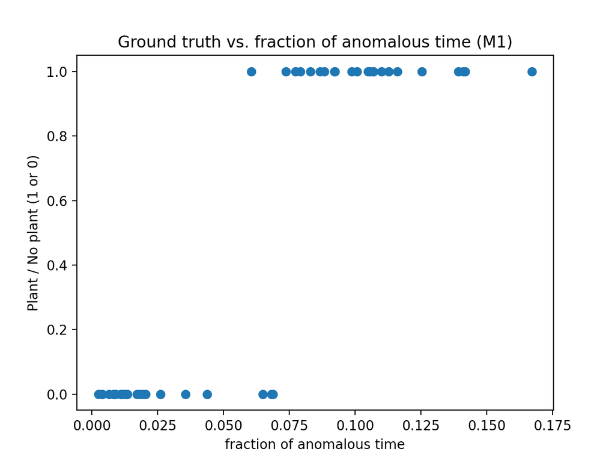

```python
with torch.no_grad():
    plt.scatter(yhat_init_1.numpy(), y_all.numpy())
    plt.title("Ground truth vs. fraction of anomalous time (M1)")
    plt.xlabel("fraction of anomalous time")
    plt.ylabel("Plant / No plant (1 or 0)")
```

# Detections

To recreate what we did previously, we extract the initial layers of the model which are flagging detections and then we filter those as before.

## Extract

```python
model_1_trunc = nn.Sequential(
    SoftThreshold(),
    RemoveSimultaneous()
)
```

```python
model_1.state_dict()
```

```
OrderedDict([('0.L1.shift', tensor(-0.2500)),
             ('0.L1.scale', tensor(-100.)),
             ('0.L2.shift', tensor(-1.)),
             ('0.L2.scale', tensor(-100.)),
             ('0.L3.shift', tensor(-2.)),
             ('0.L3.scale', tensor(100.)),
             ('3.shift', tensor(0.)),
             ('3.scale', tensor(200.))])
```

```python
for idx in ['0', '1']:
    model_1_trunc._modules[idx].load_state_dict(model_1._modules[idx].state_dict())
    # print(model_1_trunc._modules[idx].state_dict())
```

```python
Z = model_1_trunc(X_all)
```

## Filter

And now we do the thresholding as in `analysis-01-dynamics`.

```python
temp_df_list = list()
for i, z in enumerate(Z):
    temp_df = transforms1.detection_trajectories(z > 0)
    temp_df['weight'] = 1.0
    temp_df['rt_serial'] = rt_deps_to_use['rt_serial'][i]
    temp_df['crop'] = rt_deps_to_use['crop'][i]
    temp_df_list.append(temp_df)
```

```python
temp_df.head()
```

|  | start | end | paddle | electrode | weight | rt_serial | crop |
| --- | --- | --- | --- | --- | --- | --- | --- |
| 0 | 3905 | 3906 | 0 | 8 | 1.0 | EG00240 | Corn |
| 1 | 3907 | 3913 | 0 | 8 | 1.0 | EG00240 | Corn |
| 2 | 5127 | 5128 | 0 | 8 | 1.0 | EG00240 | Corn |
| 3 | 3896 | 3902 | 0 | 10 | 1.0 | EG00240 | Corn |
| 4 | 4054 | 4057 | 0 | 10 | 1.0 | EG00240 | Corn |

```python
traj_df_1 = pd.concat(temp_df_list)
```

```python
traj_df_1.shape
```

```
(12849, 7)
```

```python
traj_df_2 = transforms1.consolidate_trajectories(traj_df_1.query("electrode > 0"), grouping=['crop', 'rt_serial', 'paddle', 'electrode'], cush=6)
```

```python
traj_df_2.shape
```

```
(7576, 8)
```

```python
traj_df_3a = transforms1.flag_overlapping_trajectories(traj_df_2.sort_values(['crop', 'rt_serial', 'start', 'end']),
                                                       grouping=['crop', 'rt_serial', 'paddle'], cush=6)
# traj_df_3a.head(n=10)
```

```python
traj_df_3 = traj_df_3a.groupby(['crop', 'rt_serial', 'paddle', 'group_num']).agg({
    'start': 'min',
    'end': 'max',
    'electrode': 'min'
    }).reset_index(drop=False)
traj_df_3.shape
```

```
(4820, 7)
```

```python
# traj_df_3.head()
```

```python
# Remove trajectories that overlap in time and on adjascent paddles (we do not use modular arithmatic here, so this is only approximate).
traj_df_4a = transforms1.flag_overlapping_trajectories(traj_df_3.sort_values(['crop', 'rt_serial', 'start', 'end']), grouping=['crop', 'rt_serial'], cush=6)
traj_df_4a['num_in_group'] = traj_df_4a.groupby(['group_num'])['group_num'].transform(lambda x: len(x))
traj_df_4a['length'] = traj_df_4a['end'] - traj_df_4a['start']
traj_df_4a.shape
```

```
(4820, 10)
```

```python
traj_df_4a.head()
```

|  | crop | rt_serial | paddle | group_num | start | end | electrode | overlap_prev | num_in_group | length |
| --- | --- | --- | --- | --- | --- | --- | --- | --- | --- | --- |
| 0 | Corn | EG00054 | 10 | 1 | 36 | 37 | 20 | False | 1 | 1 |
| 1 | Corn | EG00054 | 10 | 2 | 346 | 351 | 20 | False | 1 | 5 |
| 2 | Corn | EG00054 | 10 | 3 | 378 | 396 | 20 | False | 1 | 18 |
| 3 | Corn | EG00054 | 2 | 4 | 532 | 533 | 12 | False | 6 | 1 |
| 4 | Corn | EG00054 | 10 | 4 | 534 | 550 | 8 | True | 6 | 16 |

There are a lot of trajectories that occur on just 1 or 2 paddles. If you just keep the number of trajectories that have only one active paddle, then you filter 2/3 of your detections! Whether we use 1 or 1 and 2, we still get reasonable separation of NPC and Corn below. We could also do this after the fact by modeling.

```python
traj_df_4a['num_in_group'].value_counts()
```

```
num_in_group
1     1837
2      976
3      621
4      444
5      300
6      276
7      168
8       88
9       45
11      33
10      20
12      12
Name: count, dtype: int64
```

```python
pd.crosstab(traj_df_4a['num_in_group'], traj_df_4a['crop'])
```

| crop num_in_group | Corn | NPC |
| --- | --- | --- |
| 1 | 1462 | 375 |
| 2 | 764 | 212 |
| 3 | 468 | 153 |
| 4 | 312 | 132 |
| 5 | 230 | 70 |
| 6 | 192 | 84 |
| 7 | 112 | 56 |
| 8 | 64 | 24 |
| 9 | 27 | 18 |
| 10 | 20 | 0 |
| 11 | 11 | 22 |
| 12 | 12 | 0 |

```python
# Lots of overlap in this NPC, but it doesn't all align
# traj_df_4a.query("rt_serial == 'EG00103' & num_in_group == 6")
```

```python
# We remove 2/3 of trajectories by removing things at occur at the same time!!!
traj_df_4 = traj_df_4a.query("num_in_group <= 1")
traj_df_4.shape
```

```
(1837, 10)
```

```python
# traj_df_4.head()
```

```python
traj_df_5 = traj_df_4.copy()
# traj_df_5 = traj_df_4.merge(crop_df, on='rt_serial')
traj_df_5.shape
```

```
(1837, 10)
```

```python
# traj_df_5['length'] = traj_df_5['end'] - traj_df_5['start']
traj_df_5['day']= np.floor(traj_df_5['start'] / (12 * 24)).astype(int)
traj_df_5.head()
```

|  | crop | rt_serial | paddle | group_num | start | end | electrode | overlap_prev | num_in_group | length | day |
| --- | --- | --- | --- | --- | --- | --- | --- | --- | --- | --- | --- |
| 0 | Corn | EG00054 | 10 | 1 | 36 | 37 | 20 | False | 1 | 1 | 0 |
| 1 | Corn | EG00054 | 10 | 2 | 346 | 351 | 20 | False | 1 | 5 | 1 |
| 2 | Corn | EG00054 | 10 | 3 | 378 | 396 | 20 | False | 1 | 18 | 1 |
| 9 | Corn | EG00054 | 11 | 5 | 641 | 668 | 8 | False | 1 | 27 | 2 |
| 15 | Corn | EG00054 | 0 | 8 | 972 | 998 | 7 | False | 1 | 26 | 3 |

## Plot

Let's look at the same plots we created previously. They all look very similar.

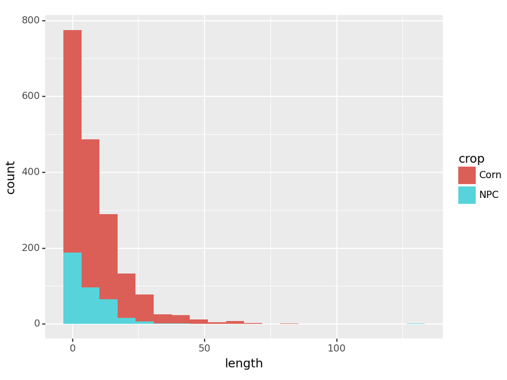

```
<Figure Size: (640 x 480)>
```

```python
gg.ggplot(traj_df_5) + gg.geom_histogram(gg.aes(x='length', fill='crop'), bins=20)
```

```python
# We integrate here, which can be critical to getting a difference if you do not filter out short-length anomalies.
traj_df_6 = traj_df_5.query("length > 6").groupby(['crop', 'rt_serial']).agg({'length': 'sum', 'start': 'size'}).reset_index(drop=False)
traj_df_6['count'] = traj_df_6.pop('start')
traj_df_6.shape
```

```
(46, 4)
```

```python
# traj_df_6.head()
```

Looking at differences in cumulative time:

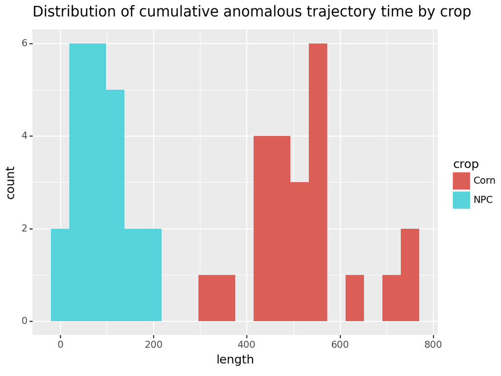

```
<Figure Size: (640 x 480)>
```

```python
gg.ggplot(traj_df_6) + gg.geom_histogram(gg.aes(x='length', fill='crop'), bins=20) + \
  gg.ggtitle("Distribution of cumulative anomalous trajectory time by crop")
```

Looking at differences in counts:

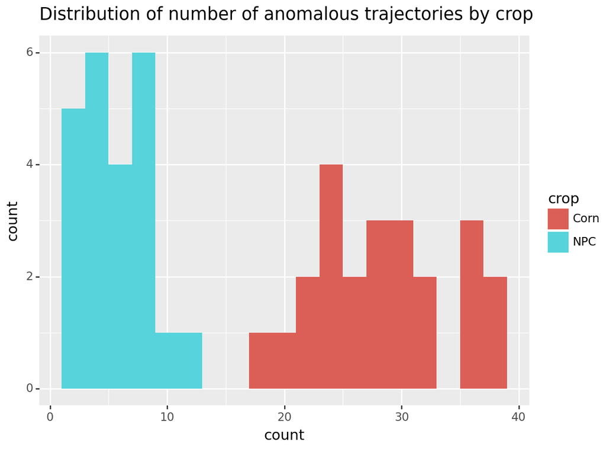

```
<Figure Size: (640 x 480)>
```

```python
gg.ggplot(traj_df_6) + gg.geom_histogram(gg.aes(x='count', fill='crop'), bins=20)  + \
  gg.ggtitle("Distribution of number of anomalous trajectories by crop")
```